# R Notebook

```r
library(xlsx)
library(ggplot2)
library(forecast)
library(gridExtra)
library(astsa)
library(zoo)
library(car)
housing <- read.xlsx("data_g5.xlsx", sheetName = "6.19 r")
head(housing)
```

|  | Fecha | X..Viviendas |
| --- | --- | --- |
| 1 | 1990-01-01 | 19.8 |
| 2 | 1990-02-01 | 19.8 |
| 3 | 1990-03-01 | 19.7 |
| 4 | 1990-04-01 | 19.7 |
| 5 | 1990-05-01 | 19.3 |
| 6 | 1990-06-01 | 19.0 |

## Question 1

### Plot the series and briefly comment on the characteristics you observe (stationarity, trend, seasonality…).

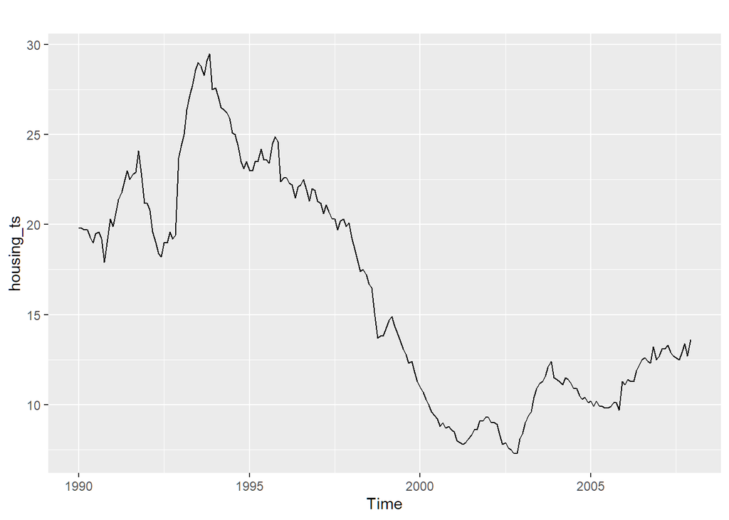

```r
housing_ts <- ts(housing[,2], frequency=12, start=c(1990,1))
autoplot(housing_ts)
```

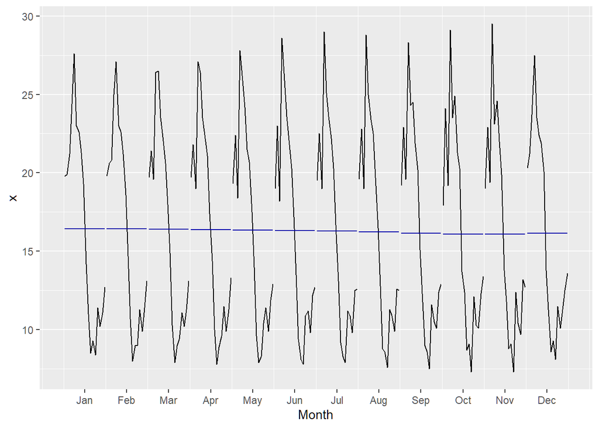

```r
#Seasonality in depth
ggmonthplot(housing_ts) #Monthly
```

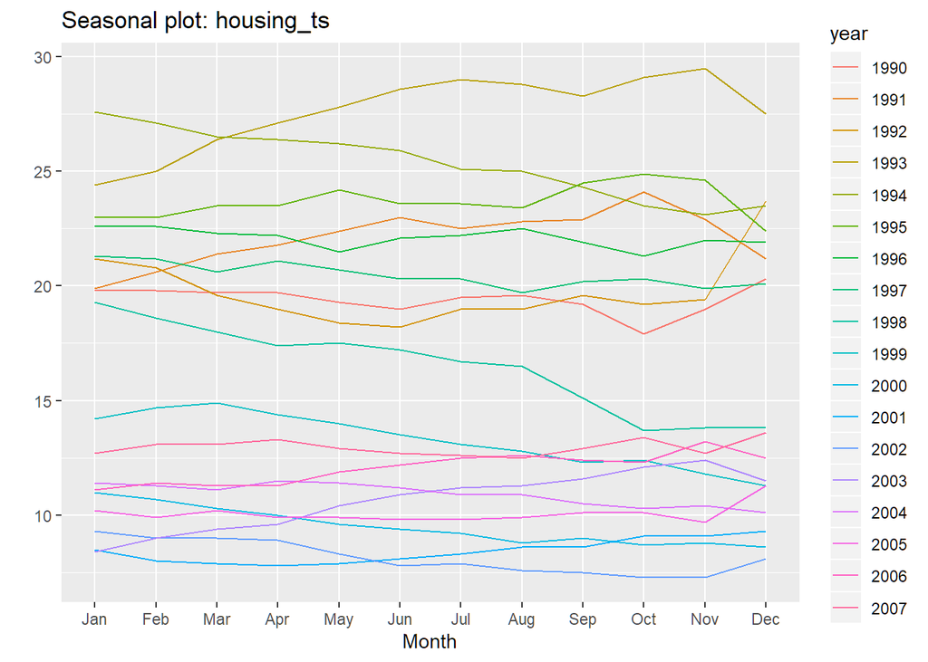

```r
ggseasonplot(housing_ts) #Yearly
```

- Trend: There is a trend over time and we can see different patterns. There is a changing trend that has a positive slope between 1991 and 1993, a negative slope between 1993 and 2003, and a positive slope from 2003 and onwards.
- Seasonality: It seems that there is no seasonality, as there is not a regularly repeating pattern related.
- Cyclical components: There is no evidence of any cyclic behaviour in the data.

Taking these observations into account, we can state that we are working with a non-stationary time Series. Even if the time series shows no seasonal or cyclical components, the presence of trends makes it non-stationary.

## Question 2.

### Obtain a plot of the decomposition of the series, using stl(). Use an additive decomposition

or a multiplicative one, depending on your data.

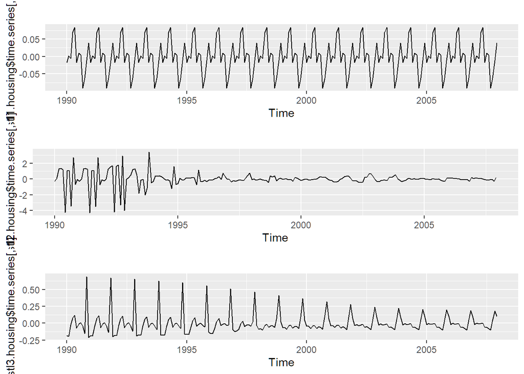

```r
#Additive decomposition
stl1.housing <- stl(housing_ts,  s.window="periodic", robust=TRUE)
stl2.housing <- stl(housing_ts,  s.window=5, robust=TRUE)
stl3.housing <- stl(housing_ts,  s.window=15, robust=TRUE)

#Compare seasonal components tunning parameter s.window
season1=autoplot(stl1.housing$time.series[,1])
season2=autoplot(stl2.housing$time.series[,1])
season3=autoplot(stl3.housing$time.series[,1])
grid.arrange(season1, season2, season3, ncol= 1)
```

We have used an additive decomposition, since there are no changes in seasonal components. We can see that using the first seasonal window (s.window = periodic), the seasonal components are small, centered around zero and more or less constant. Since the seasonality plots obtained before showed no influence of seasonal components, we will choose this seasonal window.

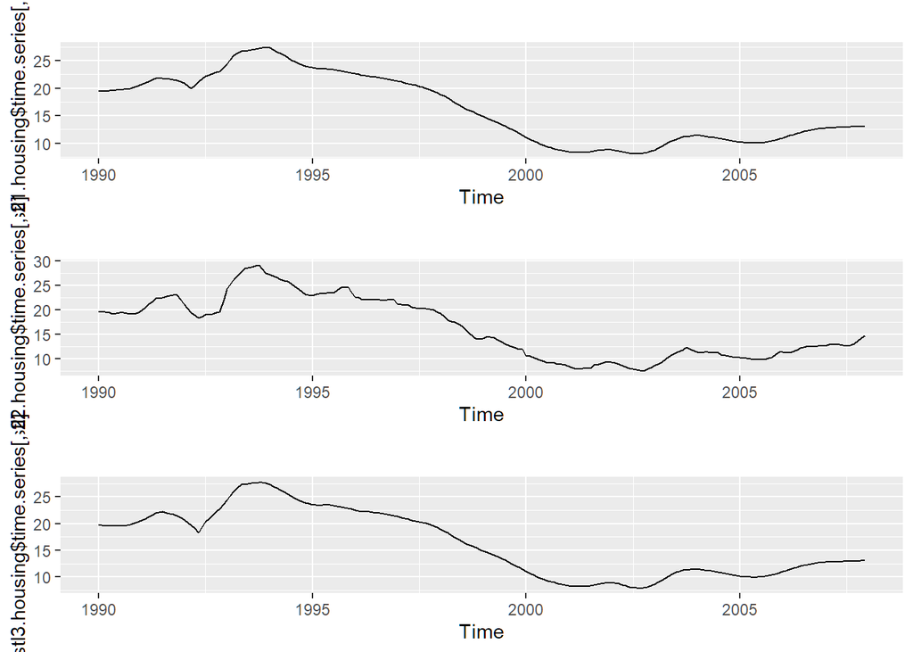

```r
stl1.housing <- stl(housing_ts, s.window="periodic", robust=TRUE)
stl2.housing <- stl(housing_ts, t.window = 5, s.window="periodic", robust=TRUE)
stl3.housing <- stl(housing_ts, t.window = 15, s.window="periodic", robust=TRUE)

#Compare trends
trend1 = autoplot(stl1.housing$time.series[,2])
trend2=autoplot(stl2.housing$time.series[,2]) #more wiggly trend
trend3=autoplot(stl3.housing$time.series[,2])
grid.arrange(trend1, trend2, trend3, ncol= 1)
```

Keeping a periodic window for the seasonal components (assuming they are equal across the years), we can see that using the second trend window (t.window = 5), produces the trend that better captures the structure of the data. Thus, we will choose it.

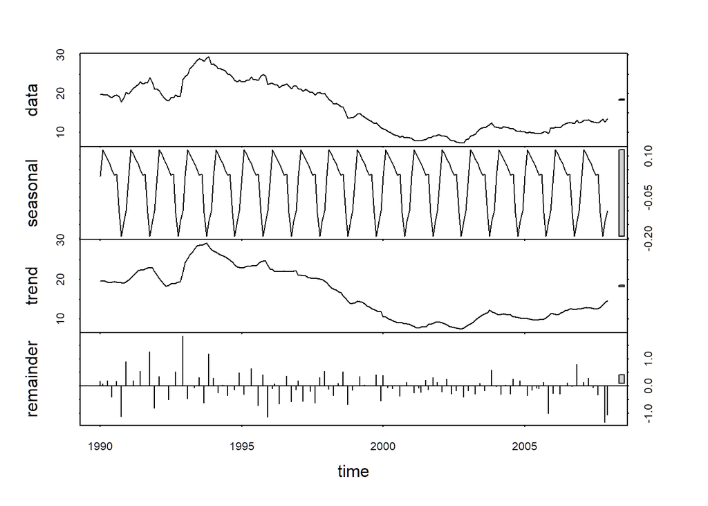

```r
#Final decomposition
stl.housing <- stl(housing_ts, t.window=5, s.window="periodic", robust=TRUE)
#stl.housing #seasonal, trend, remainder
plot(stl.housing)
```

```r
# seasonal factors
seasonal.factors<-stl.housing$time.series[,1]
min(seasonal.factors)
```

```
## [1] -0.1924054
```

```r
max(seasonal.factors)
```

```
## [1] 0.1239283
```

```r
# remainder
housing.remainder<-stl.housing$time.series[,3]
min(housing.remainder)
```

```
## [1] -1.338125
```

```r
max(housing.remainder)
```

```
## [1] 1.844717
```

```r
mean(housing.remainder)
```

```
## [1] -0.01529572
```

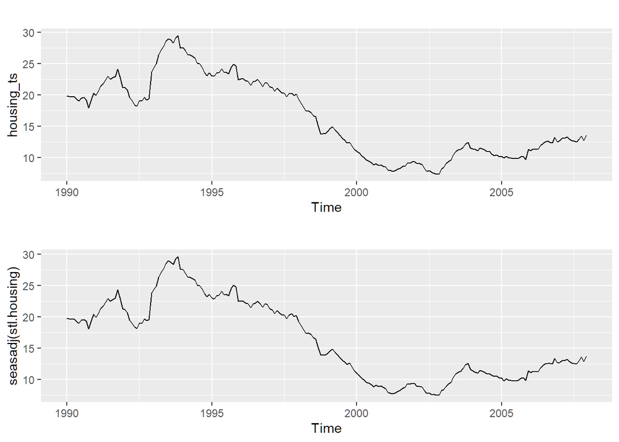

```r
#plotting the original series and the seasonal adjusted one, to see the trend
pl1=autoplot(housing_ts)
pl2=autoplot(seasadj(stl.housing))
grid.arrange(pl1, pl2, ncol= 1)
```

Watching the decomposition plot resulting from the selected windows, we can see that the seasona components have low constant values that are centered around zero ([-0.192,0.124]). The structure of the data is captured well by the trend component and the seasonal adjusted series is just like the original one. The remainder values are somewhat big ([-1.34,1.84]), but have zero mean (-0.0153).

### Use the function forecast() to forecast future values.

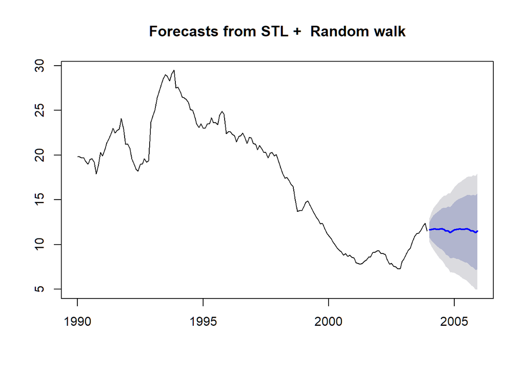

```r
#Training and testing data split
housing.train=window(housing_ts, end=2004-0.001) #~0.8
housing.test=window(housing_ts,start=2004) #~0.2
#The slope at the transition between testing and training datasets influences how easy is to predict the future values. The year at which we divide the time series determines which method has the lowest RMSE.

#forecasting with stl(): different methods: naive, ets, arima, rwdrift
stl.housing <- stl(housing.train, t.window=5, s.window="periodic", robust=TRUE)

#naive
fcst=forecast(stl.housing, method="naive", h=24)
plot(fcst)
```

```r
#fcst$mean
# Validation: test error  RMSE
sqrt(mean((fcst$mean - housing.test)^2, na.rm=TRUE))
```

```
## [1] 1.284069
```

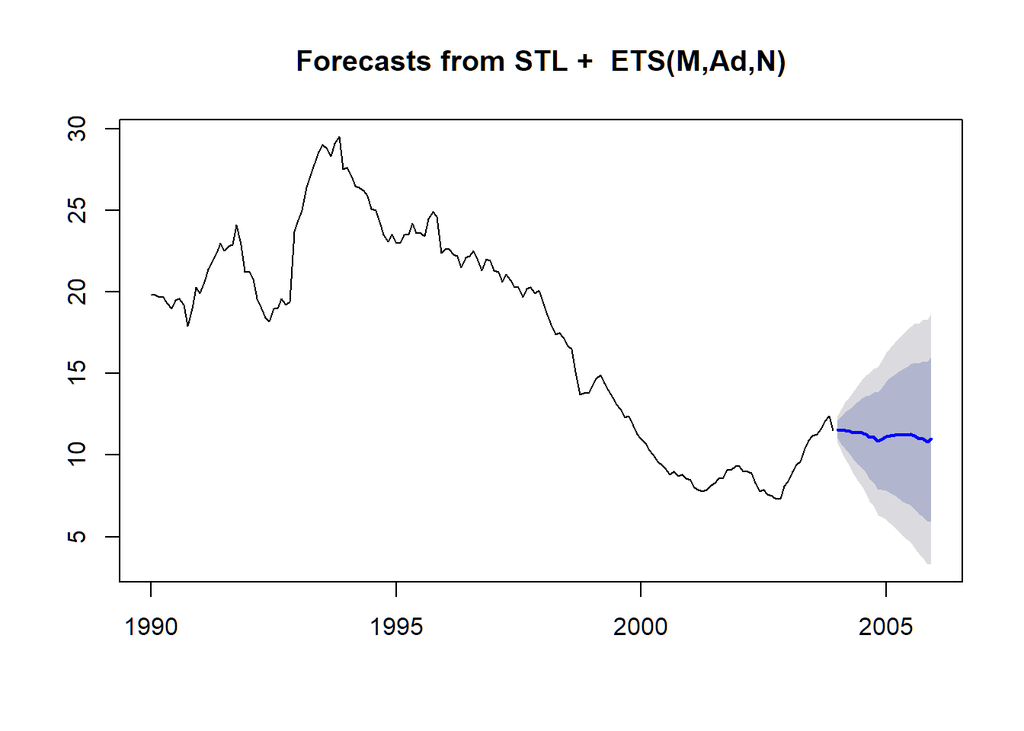

```r
#ets
fcst=forecast(stl.housing, method="ets", h=24)
plot(fcst)
```

```r
#fcst$mean
# Validation: test error  RMSE
sqrt(mean((fcst$mean-housing.test)^2, na.rm=TRUE))
```

```
## [1] 0.8816627
```

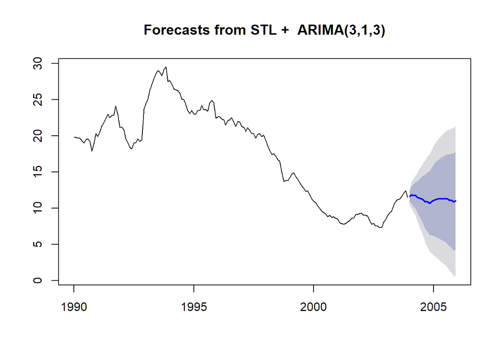

```r
#arima
fcst=forecast(stl.housing, method="arima", h=24)
plot(fcst)
```

```r
#fcst$mean
# Validation: test error  RMSE
sqrt(mean((fcst$mean-housing.test)^2, na.rm=TRUE))
```

```
## [1] 0.9045205
```

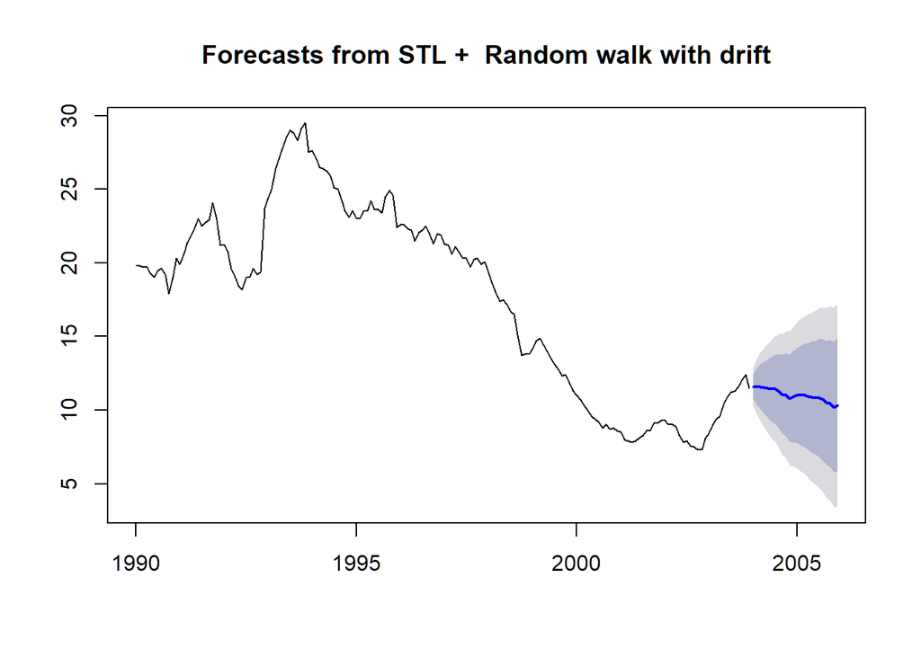

```r
#rwdrift
fcst=forecast(stl.housing, method="rwdrift", h=24)
plot(fcst)
```

```r
#fcst$mean
# Validation: test error  RMSE
sqrt(mean((fcst$mean-housing.test)^2, na.rm=TRUE)) #Lowest RMSE
```

```
## [1] 0.6903909
```

Using stl() to forecast, we can see that using the random walk with drift method to predict future values results in the lowest RMSE.

### Does the remainder look like a white noise to you? Answer to this point just visually or plot the ACF and PACF of the remainder part.

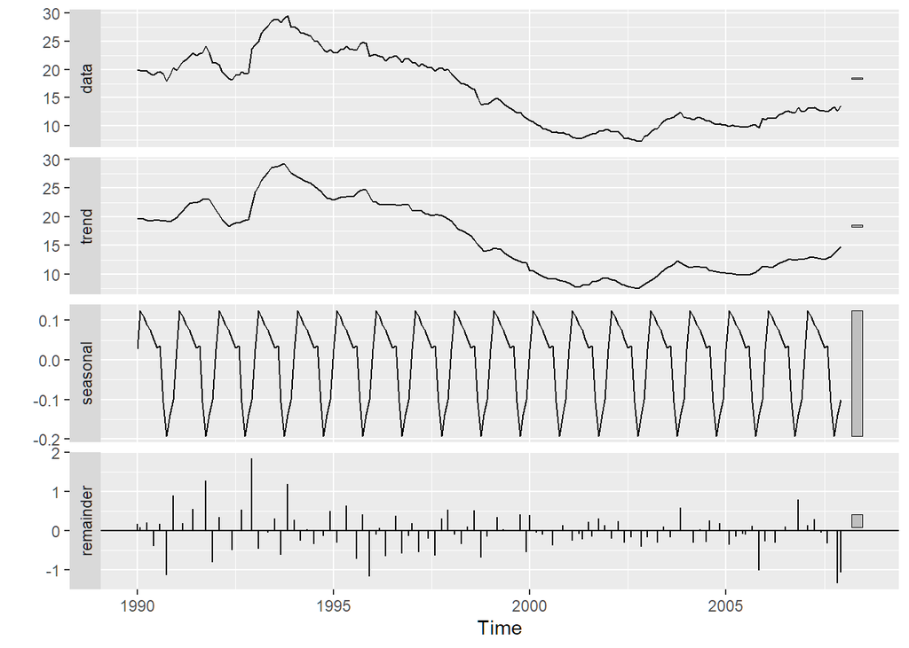

```r
#Remainder
stl.housing <- stl(housing_ts, t.window=5, s.window="periodic", robust=TRUE)
autoplot(stl.housing)
```

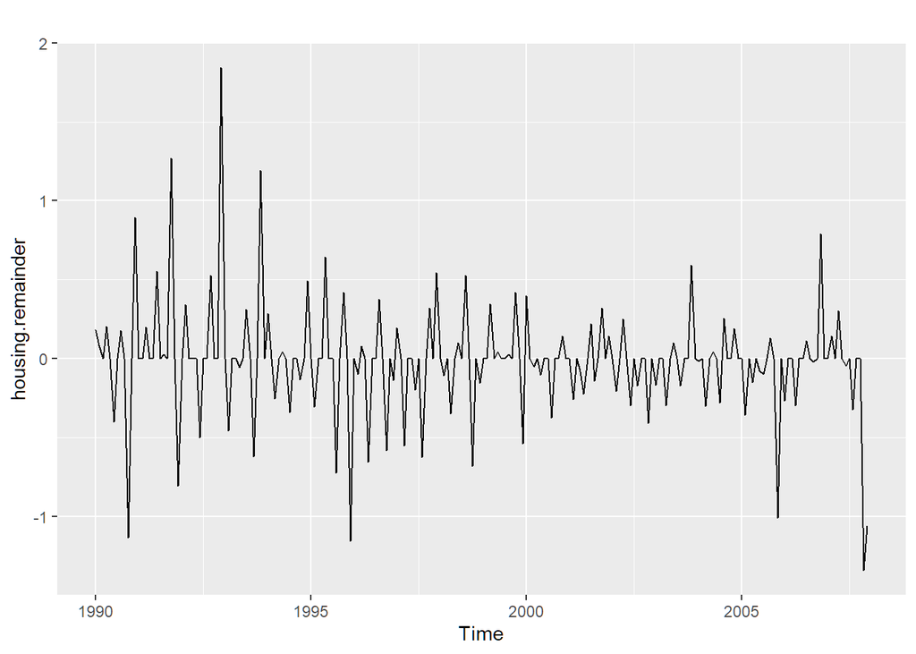

```r
housing.remainder<-stl.housing$time.series[,3]
autoplot(housing.remainder)
```

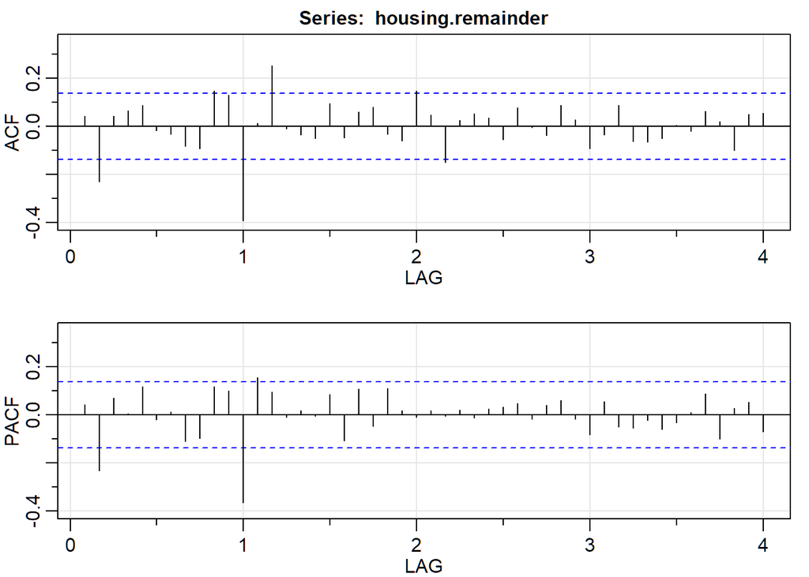

```
##         ACF  PACF
##  [1,]  0.04  0.04
##  [2,] -0.23 -0.23
##  [3,]  0.04  0.07
##  [4,]  0.07  0.01
##  [5,]  0.09  0.12
##  [6,] -0.02 -0.02
##  [7,] -0.03  0.01
##  [8,] -0.08 -0.11
##  [9,] -0.09 -0.10
## [10,]  0.15  0.12
## [11,]  0.13  0.10
## [12,] -0.39 -0.36
## [13,]  0.01  0.15
## [14,]  0.25  0.09
```

[output cut: 34 more lines]

```r
#ACF and PACF
acf2(housing.remainder)
```

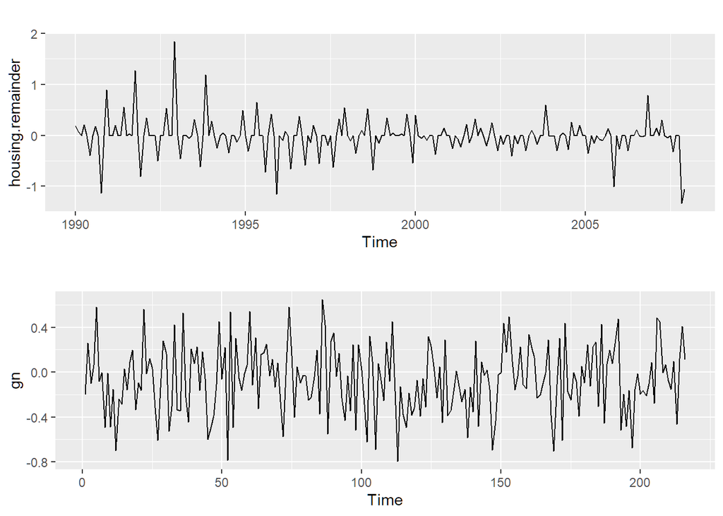

```r
#Gaussian noise
gn = rnorm(length(housing.remainder),mean=mean(housing.remainder[-1]),sd=sd(housing.remainder[-1]))
gn=ts(gn)

#Comparison
plot1=autoplot(housing.remainder)
plot2=autoplot(gn)
grid.arrange(plot1, plot2, ncol= 1)
```

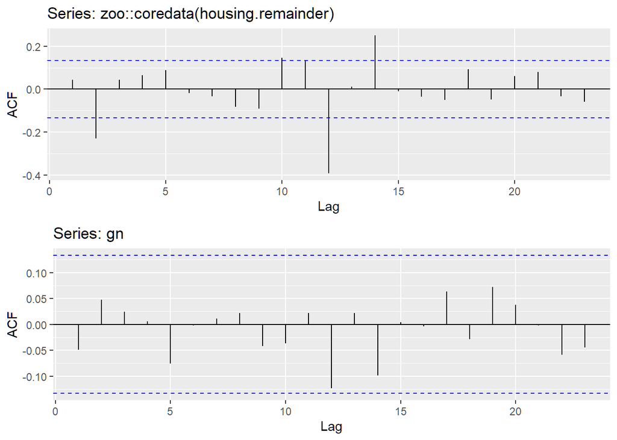

```r
plot3=ggAcf(zoo::coredata(housing.remainder))
plot4=ggAcf(gn) #comparing with gaussian noise
grid.arrange(plot3,plot4,ncol=1)
```

The remainder does not look like gaussian noise, since it does not have a constant variance.